# Working with Cytometry Data in R

Mass Cytometry Course 2019

Benjamin Reisman

March 22, 2019

# Why Use R?

*“R is a free software environment for statistical computing and graphics”*

Compared to Commercial Flow Cytometry Software, R has the following advantages:

- Reproducible (Data + Code = Figures)
- Flexible (This presentation was created in R!)
- Nice Graphics (ggplot2)
- Great for analysis pipelines and frequently used workflows
- Newest analysis techniques
- Free!

# Goals of this talk:

In R, things that look hard are easy, but things that look easy are (a little) hard.

- Demonstrate why you might want to work in R
- Overcoming the biggest obstacles to working in R
  - Getting data into R
  - Tidying data into the right format for analysis
- Introduce some advanced analysis techniques
- Provide examples and links to resources for learning more.

# Representing Data in R

- Matrix: An $n*m$ array of items, all of the single class
- Data Frame: An $n*m$ array of items, but each column can be a different class

*Example: The iris dataset: measurements of 50 flowers of 3 species of iris*

```r
head(iris)
```

```
##   Sepal.Length Sepal.Width Petal.Length Petal.Width Species
## 1          5.1         3.5          1.4         0.2  setosa
## 2          4.9         3.0          1.4         0.2  setosa
## 3          4.7         3.2          1.3         0.2  setosa
## 4          4.6         3.1          1.5         0.2  setosa
## 5          5.0         3.6          1.4         0.2  setosa
## 6          5.4         3.9          1.7         0.4  setosa
```

# Representing Data in R: Data Frames

Data Frame: An $n*m$ array of items, but each column can be a different class

```r
class(iris)
```

```
## [1] "data.frame"
```

```r
str(iris)
```

```
## 'data.frame':    150 obs. of  5 variables:
##  $ Sepal.Length: num  5.1 4.9 4.7 4.6 5 5.4 4.6 5 4.4 4.9 ...
##  $ Sepal.Width : num  3.5 3 3.2 3.1 3.6 3.9 3.4 3.4 2.9 3.1 ...
##  $ Petal.Length: num  1.4 1.4 1.3 1.5 1.4 1.7 1.4 1.5 1.4 1.5 ...
##  $ Petal.Width : num  0.2 0.2 0.2 0.2 0.2 0.4 0.3 0.2 0.2 0.1 ...
##  $ Species     : Factor w/ 3 levels "setosa","versicolor",..: 1 1 1 1 1 1 1 1 1 1 ...
```

# Representing Data in R: Matricies (1)

- Matrix: An $n*m$ array of items, all of the single class

```r
iris_matrix <- as.matrix(iris)
head(iris_matrix)
```

```
##      Sepal.Length Sepal.Width Petal.Length Petal.Width Species
## [1,] "5.1"        "3.5"       "1.4"        "0.2"       "setosa"
## [2,] "4.9"        "3.0"       "1.4"        "0.2"       "setosa"
## [3,] "4.7"        "3.2"       "1.3"        "0.2"       "setosa"
## [4,] "4.6"        "3.1"       "1.5"        "0.2"       "setosa"
## [5,] "5.0"        "3.6"       "1.4"        "0.2"       "setosa"
## [6,] "5.4"        "3.9"       "1.7"        "0.4"       "setosa"
```

```r
str(iris_matrix)
```

```
##  chr [1:150, 1:5] "5.1" "4.9" "4.7" "4.6" "5.0" "5.4" "4.6" "5.0" ...
##  - attr(*, "dimnames")=List of 2
##   ..$ : NULL
##   ..$ : chr [1:5] "Sepal.Length" "Sepal.Width" "Petal.Length" "Petal.Width" ...
```

```r
#that doesn't look right...
```

# Representing Data in R: Matricies (2)

- Matrix: An $n*m$ array of items, all of the single class

```r
#only the numeric columns, 1:4
iris_matrix <- as.matrix(iris[1:4])
head(iris_matrix)
```

```
##      Sepal.Length Sepal.Width Petal.Length Petal.Width
## [1,]          5.1         3.5          1.4         0.2
## [2,]          4.9         3.0          1.4         0.2
## [3,]          4.7         3.2          1.3         0.2
## [4,]          4.6         3.1          1.5         0.2
## [5,]          5.0         3.6          1.4         0.2
## [6,]          5.4         3.9          1.7         0.4
```

```r
str(iris_matrix)
```

```
##  num [1:150, 1:4] 5.1 4.9 4.7 4.6 5 5.4 4.6 5 4.4 4.9 ...
##  - attr(*, "dimnames")=List of 2
##   ..$ : NULL
##   ..$ : chr [1:4] "Sepal.Length" "Sepal.Width" "Petal.Length" "Petal.Width"
```

# Defining Tidy Data

To work with data in R, it’s best to have ‘tidy data,’ which meets the following criteria:

1. Each variable must have its own column.
2. Each observation must have its own row.
3. Each value must have its own cell.

…but cytometry data is not usually tidy.

*For more information, see*: Wickham, Hadley. “Tidy data.” *Journal of Statistical Software* 59.10 (2014): 1-23.

# Representing Flow Cytometry Data in R

A number of specialized classes have been developed to represent high dimensional bioinformatics data:

- Biocondutor:
  - `SummarizedExperiment` - created to represent genetic data (RNAseq, microarray, etc…)
- `flowcore` (RGlab)
  - `FlowFrame` - Representation of an FCS file in R
  - `FlowSet` - Container for multiple FlowFrames + Metadata
- `flowWorkspace` (RGlab)
  - `GatingSet`- A FlowSet + associated gating hierarchy

# Representing Flow Cytometry Data in R

A cytometry experiment may include:

- FCS files
- Compensations (FACS)
- Transformations
- Panels
- Gates + Populations
- Metadata

… but those aren’t neatly represented in R:

| Traditional Object | FlowCore Object | R Equivalent |
| --- | --- | --- |
| FCS File | FlowFrame | Matrix |
| Bunch of FCS File | FlowSet | List of matrices + pData |
| Gated Experiment | Gatingset | - |

# It’s easy to get flow cytometry data into R with the right tools

First we’ll need to load a few packages…

```r
library(CytobankAPI) #connects to cytobank
library(flowWorkspace)#loads flowcore, flowWorkspace
library(CytoML) #Used to read in gating files
library(cytotidyr) #for importing cytobank experiments, and tidying
library(dplyr) #for manipulating data
library(tidyr) #for rearranging data from wide to long
library(ggplot2)
```

and find our files…

```r
fcs_paths <- list.files(pattern = ".fcs", recursive = T)
print(fcs_paths)
```

```
## [1] "KCL Guys Data/20180321-01 Group 1 Helios B Post-viSNE_Ungated.fcs.density.fcs.cluster.fcs"
## [2] "KCL Guys Data/20180321-02 Group 2 Helios A Post-viSNE_Ungated.fcs.density.fcs.cluster.fcs"
## [3] "KCL Guys Data/20180321-03 Group 3 Helios A Post-viSNE_Ungated.fcs.density.fcs.cluster.fcs"
## [4] "KCL Guys Data/20180321-04 Group 4 Helios B Post-viSNE_Ungated.fcs.density.fcs.cluster.fcs"
```

# Connecting to Cytobank

Using `CytobankAPI` and `Cytotidyr` we’ll read in our experiment information from cytobank. This includes:

- gates
- transformations
- panels
- sample tags.

```r
token <- "eyJ0eXAiOiJKV1QiLCJhbGciOiJIUzI1NiJ9.eyJqdGkiOiIwNTY2MjlhYjc0YzA2ZWE3Njk0YzQ2NWM2YWM3MWIwMyIsImV4….MXnBJnOx4O2WutoK3U8OgNtaAo9pxnzKBNl8v8szGCY"
cyto_session <- authenticate("vanderbilt", auth_token = token)
experiment.id <- 29958
exp_info <- fetchCytobankExperiment(cyto_session, experiment.id)
```

# Reading in the Data

First we’ll read in the data as a flowSet

```r
myflowset <- flowCore::read.flowSet(fcs_paths)
```

Then we’ll convert it to a gatingSet

```r
mygatingset <- flowWorkspace::GatingSet(myflowset)
```

```
## ....done!
```

# Applying Transformations, Gates, Panels:

Next we’ll:

- rescale the data using the defined asinh transformation for the approraite channels:
- rename the channels according to our panel
- apply gates to the gatingset
- convert the data back to a flowset

```r
mygatingset <- flowWorkspace::transform(mygatingset, exp_info$transforms)
markernames(mygatingset) <- exp_info$panels$`Panel 1`
CytoML::gating(exp_info$gates, mygatingset)
```

```
## B Cells
```

```
## T Cells
```

```
## CD4s
```

```
## CD8s
```

```
## ....done!
```

```r
myflowset_preprocessed <- flowWorkspace::getData(mygatingset)
```

# Converting the flowset to a tidy

In order to work with our data using R, we’ll need to convert it to a data frame, using the `as.data.frame` function from cytotidyr

```r
mydataframe <- as.data.frame(myflowset_preprocessed, use_longnames = T) %>%
  mutate(`FCS Filename` = basename(`FCS Filename`)) %>%
  mutate(Group = substr(`FCS Filename`, 13, 19))
str(mydataframe)
```

```
## 'data.frame':    100000 obs. of  77 variables:
##  $ Time               : num  30.8 86.5 96.9 115.2 143.5 ...
##  $ Event_length       : num  28 15 15 15 15 14 23 14 22 17 ...
##  $ 89Y_CD45 (v)       : num  5.09 3.96 4.38 4.25 4.39 ...
##  $ 102Pd              : num  0 0 0 0 0 0 0 0 0 0 ...
##  $ 103Rh_Viability (v): num  1.62 0 0 0 0 ...
##  $ 104Pd              : num  0.015 0 0 0 0 ...
##  $ 105Pd              : num  0 0 0 0.182 0 ...
##  $ 106Pd              : num  0 0 0 0 0 0 0 0 0 0 ...
##  $ 108Pd              : num  0 0 0 0 0 0 0 0 0 0 ...
##  $ 110Pd              : num  0 0 0 0 0 0 0 0 0 0 ...
##  $ 113In              : num  0 0 0 0 0 0 0 0 0 0 ...
##  $ 114Cd              : num  0 0 0 0 0 0 0 0 0 0 ...
##  $ 115In              : num  0 0 0 0 0 0 0 0 0 0 ...
##  $ 120Sn              : num  0 0 0 0 0.014 ...
```

[output cut: 63 more lines]

# Making Cytometry Figures in R (1)

One thing we may want to do is reproduce the same tSNE figure we made on cytobank:

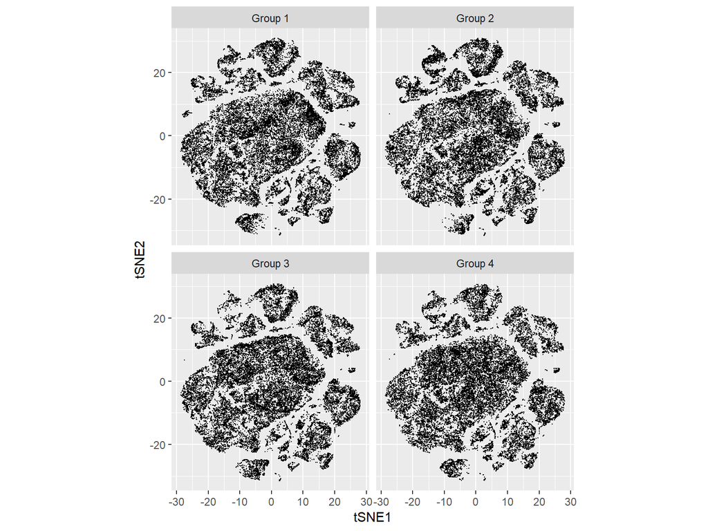

```r
ggplot(mydataframe, aes(x = tSNE1, y = tSNE2)) +
  geom_point(shape = ".") +
  coord_fixed() +
  facet_wrap(~Group)
```

# Making Cytometry Figures in R (2)

We can also customize our plots in ways that are not easy to do in cytobank:

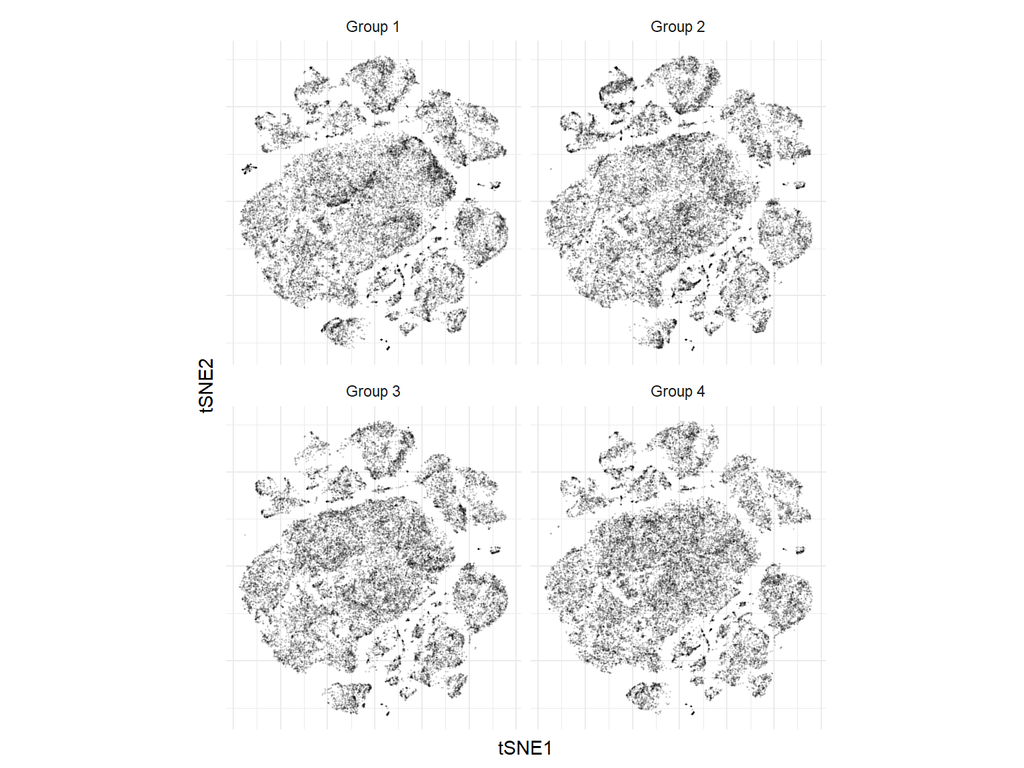

```r
ggplot(mydataframe, aes(x = tSNE1, y = tSNE2)) +
  geom_point(shape = 16, alpha = 0.2, size = 0.2) +
  coord_fixed() +
  facet_wrap(~Group) +
  scale_color_viridis_c(option = "A") +
  theme_minimal() +
  theme(axis.text = element_blank())
```

# Making Cytometry Figures in R (3)

We may also want to plot multiple channels in the same plot with faceting:

- Two differences between this plot compared and the last plot:
  - Marker intensity is mapped to color
  - Markers are facetted across mutliple subplots
- In our current [wide] data.frame, intensity is spread across multiple columns
- The plot we want to make requires a [long] data.frame with a single column for intensity + a new column for markers
- We’ll need to ‘tidy’ the data to the right format for our plot.

```r
dim((mydataframe))
```

```
## [1] 100000     77
```

```r
element2 <- function(x){unlist(lapply(strsplit(x, split = "_|\ "),"[[", 2))}
mydataframe.long <- mydataframe %>%
  as_tibble() %>%
  gather(marker, intensity, contains("(V)")) %>% # <- this is the key step
  separate(marker, c("channel", "marker", "drop"), sep= "_|\ ") %>%
  as_tibble()
dim((mydataframe.long))
```

```
## [1] 2100000      60
```

# Making Cytometry Figures in R (4)

Then we’ll make our plot:

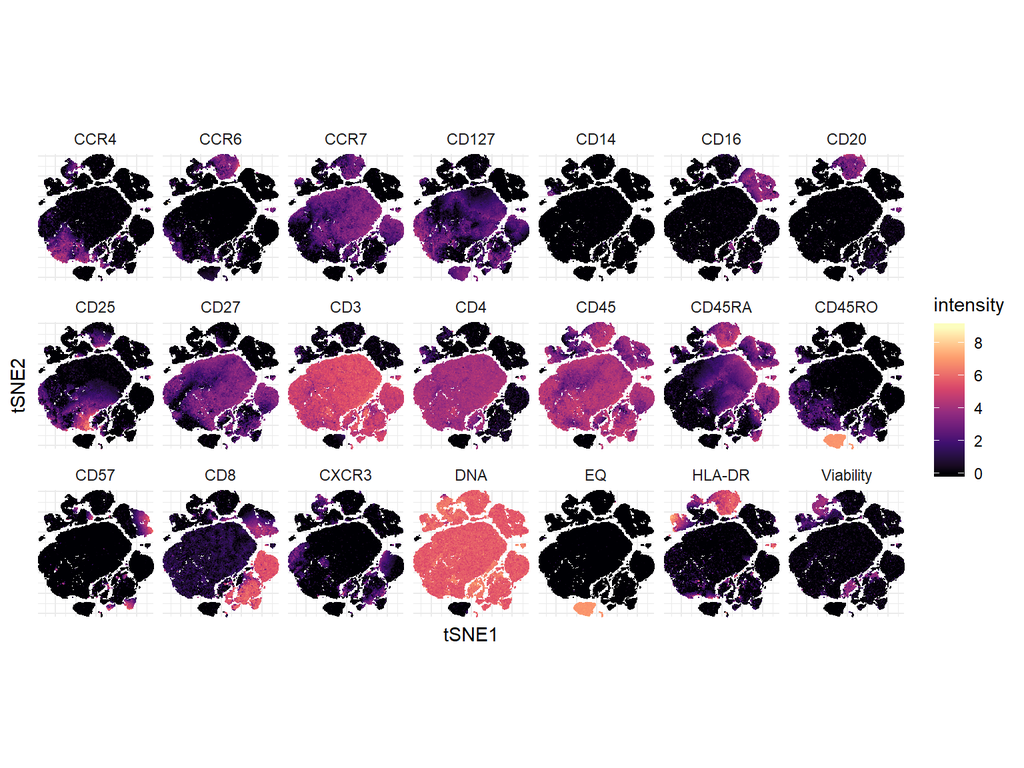

```r
mydataframe.long %>%
  ggplot(aes(x = tSNE1, y = tSNE2, col = intensity)) +
  geom_point(shape = ".") +
  scale_x_continuous(expand = c(0,0)) +
  scale_y_continuous(expand = c(0,0)) +
  scale_color_viridis_c(option = "A") +
  coord_fixed() +
  facet_wrap(~marker, nrow = 3) +
  theme_minimal() +
  theme(axis.text = element_blank())
```

# Applying alternative dimensionality reduction techniques (1)

One of the advantages of R is that we’re not limited to the dimensionality reduction techniques that are included in commercial packages.

- Ex: Uniform Manifold Approximation and Projection (UMAP)
  - McInnes L. et al. arXiv, 2018
- Advantages of UMAP vs. tSNE
  - Faster (minutes vs. hours)
  - Scalable ($f(n)$ vs. $f(n*log(n))$)
  - Preserves local+global structure
  - Other nice features (embedding new points, supervised learning, etc…)

# Applying alternative dimensionality reduction techniques (2)

First we’ll need to create a seperate matrix containing the columns we want to be included in the dimensionality reduction.

```r
mymatrix <- mydataframe %>%
  select(contains("(V)")) %>%
  as.matrix()
```

Then we’ll run it through the uwot implementation of UMAP

```r
#install.packages("devtools")
#devtools::install_github("jlmelville/uwot")
library(uwot)
myumap <- umap(mymatrix, init = "PCA")
str(myumap)
```

```
##  num [1:100000, 1:2] -7.8976 1.4036 8.1545 -6.3052 0.0437 ...
##  - attr(*, "scaled:center")= num [1:2] -0.0042 0.061
```

# Applying alternative dimensionality reduction techniques (3)

Next, we’ll rejoin the two new UMAP columns to our original dataframe, and make our plot:

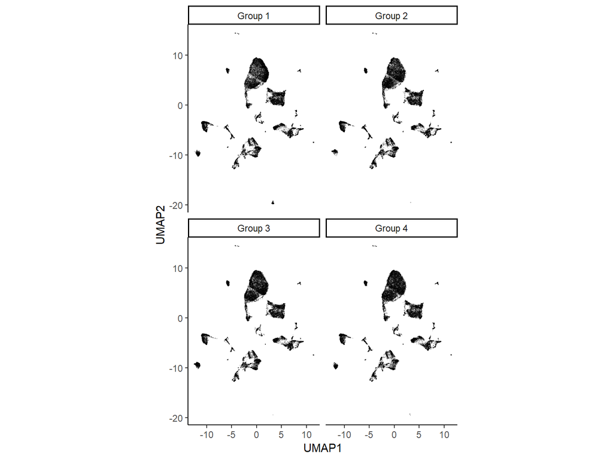

# Applying alternative dimensionality reduction techniques (4)

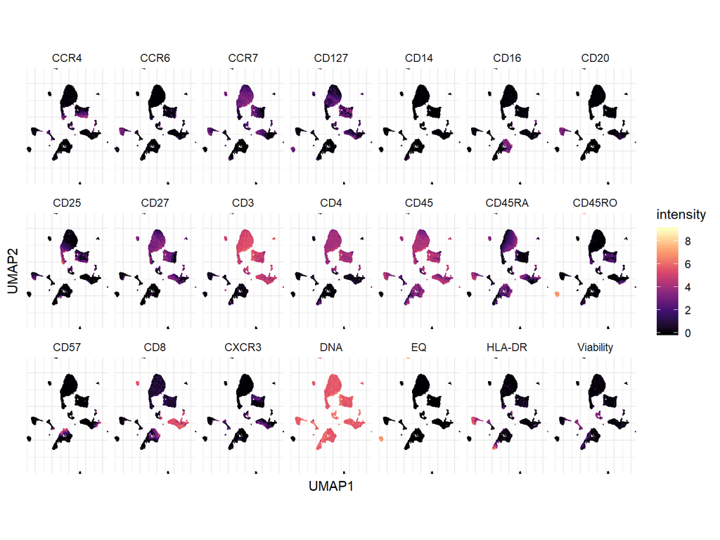

```r
mydataframe %>%
  bind_cols(as.data.frame(myumap)) %>%
  as_tibble() %>%
  gather(marker, intensity, contains("(V)")) %>% # <- this is the key step
  separate(marker, c("channel", "marker", "drop"), sep= "_|\ ") %>%
  ggplot(aes(x = UMAP1, y = UMAP2, col = intensity)) +
  geom_point(shape = ".") +
  scale_x_continuous(expand = c(0,0)) +
  scale_y_continuous(expand = c(0,0)) +
  scale_color_viridis_c(option = "A") +
  coord_fixed() +
  facet_wrap(~marker, nrow = 3) +
  theme_minimal() +
  theme(axis.text = element_blank())
```

# Applying alternative dimensionality reduction techniques (5)

We can also plot our data as a map:

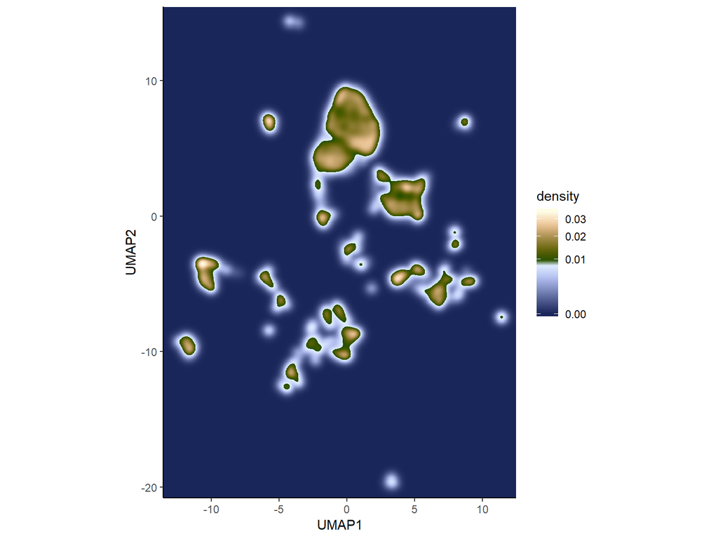

```r
library(scico)
axis.max <- apply(myumap, 2, max) + 1
axis.min <- apply(myumap, 2, min) - 1

mydataframe %>%
  bind_cols(as.data.frame(myumap)) %>%
  ggplot(aes(x=UMAP1, y = UMAP2)) +
  stat_density_2d(h = c(1, 1),
                  n = 1024,
                  geom = "raster",
                  contour = F,
                  aes(fill = stat(density))) +
  scale_fill_scico(palette = "oleron", name = "density", trans = "sqrt") +
  scale_x_continuous(expand = c(0,0), limits = c(axis.min[1], axis.max[1])) +
  scale_y_continuous(expand = c(0,0), limits = c(axis.min[2], axis.max[2])) +
  theme_classic() +
  coord_fixed()
```

# Clustering in R

We can also apply a clustering algorithm to our dimensionality reduced data.

- Density-based spatial clustering of applications with noise (DBSCAN)
  - No need to specify number of clusters
  - Few parameters to tune (eps and minPts)
  - Fast + scalable

```r
#install.packages("dbscan")
library(dbscan)
mydbscan <- dbscan(myumap, eps = 0.3, minPts = 150)
mydbscan
```

```
## DBSCAN clustering for 100000 objects.
## Parameters: eps = 0.3, minPts = 150
## The clustering contains 22 cluster(s) and 453 noise points.
##
##     0     1     2     3     4     5     6     7     8     9    10    11
##   453  2073  8279 37863  4422  6956  2559 15082  1102  1219  2836  2133
##    12    13    14    15    16    17    18    19    20    21    22
##  2693  6472   376  1731  1722   677   522   208   353   176    93
##
## Available fields: cluster, eps, minPts
```

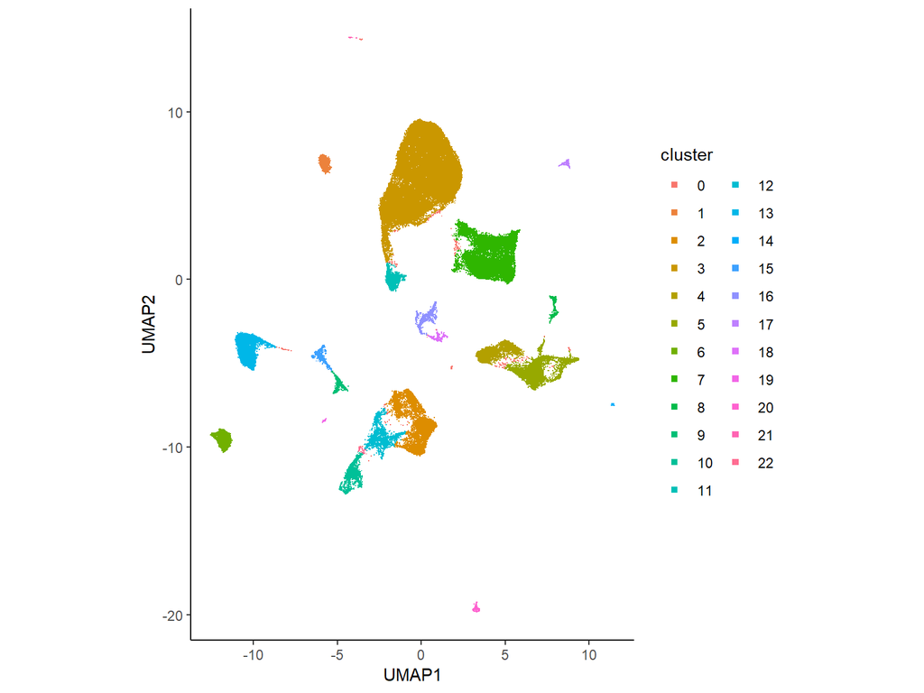

```r
mydataframe %>%
  bind_cols(as.data.frame(myumap)) %>%
  mutate(cluster = as.factor(mydbscan$cluster)) %>%
 # dplyr::filter(cluster == 1:3) %>%
  ggplot(aes(x=UMAP1, y = UMAP2, col = cluster)) +
  geom_point(shape = ".") +
  scale_color_discrete(guide = guide_legend(override.aes = list(shape = 15))) +
  coord_fixed() +
  theme_classic()
```

# Understanding our clusters

We have clusters, but how can we understand what makes them distinct?

- Marker Enrichment Modeling (MEM)
- Heatmaps (see example below)

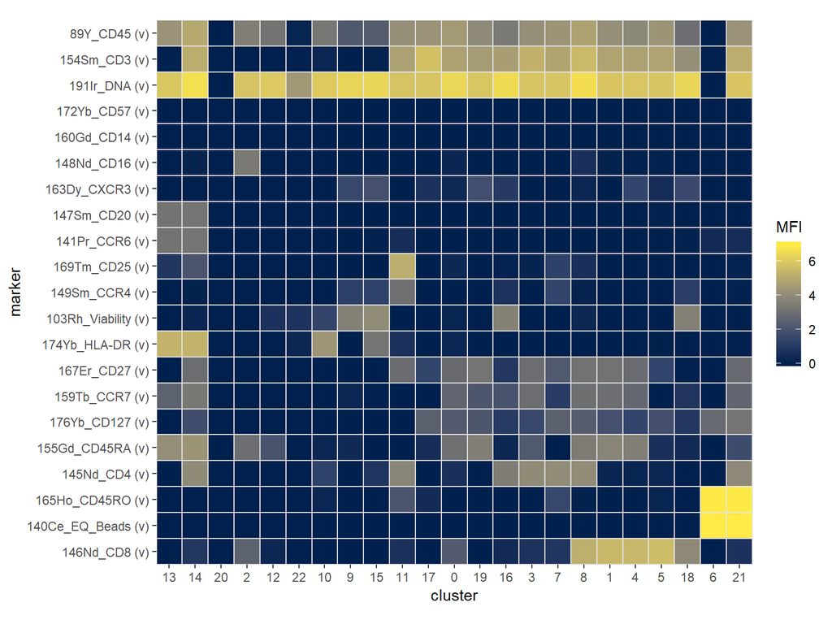

```r
library(tibble)
library(scico)
library(seriation)

myheatmap <- mydataframe %>%
  bind_cols(as.data.frame(myumap)) %>%
  mutate(cluster = as.factor(mydbscan$cluster)) %>%
  gather(marker, intensity, contains("(V)")) %>% # <- this is the key step
  group_by(cluster, marker) %>%
  summarise(MFI = median(intensity)) %>%
  select(marker, MFI, cluster) %>%
  spread(marker, MFI)

myheatmap.mat <- myheatmap %>%
  ungroup() %>%
  column_to_rownames("cluster") %>%
  as.matrix()

matrix.dist.row <- dist((myheatmap.mat))
matrix.dist.col <- dist(t(myheatmap.mat))
row.order <- seriation::get_order(seriate(matrix.dist.row, method = "HC"))
col.order <- seriation::get_order(seriate(matrix.dist.col, method = "HC"))

myheatmap %>%
  ungroup() %>%
  gather(marker, MFI, -cluster) %>%
  mutate(marker = factor(marker, levels = colnames(myheatmap.mat)[(col.order)])) %>%
  mutate(cluster = factor(cluster, levels = rownames(myheatmap.mat)[(row.order)])) %>%
  ggplot(aes(x=cluster, y = marker,fill = MFI)) +
  geom_tile(color = "grey90", size = 0.5) +
  scale_fill_viridis_c(option = "E") +
  scale_x_discrete(expand = c(0,0)) +
  scale_y_discrete(expand = c(0,0)) +
  coord_fixed()
```

# What else is out there

[CyTOFkit](https://github.com/JinmiaoChenLab/cytofkit)

- Chen, H, et al., *PLOS Computational Biology* 2016

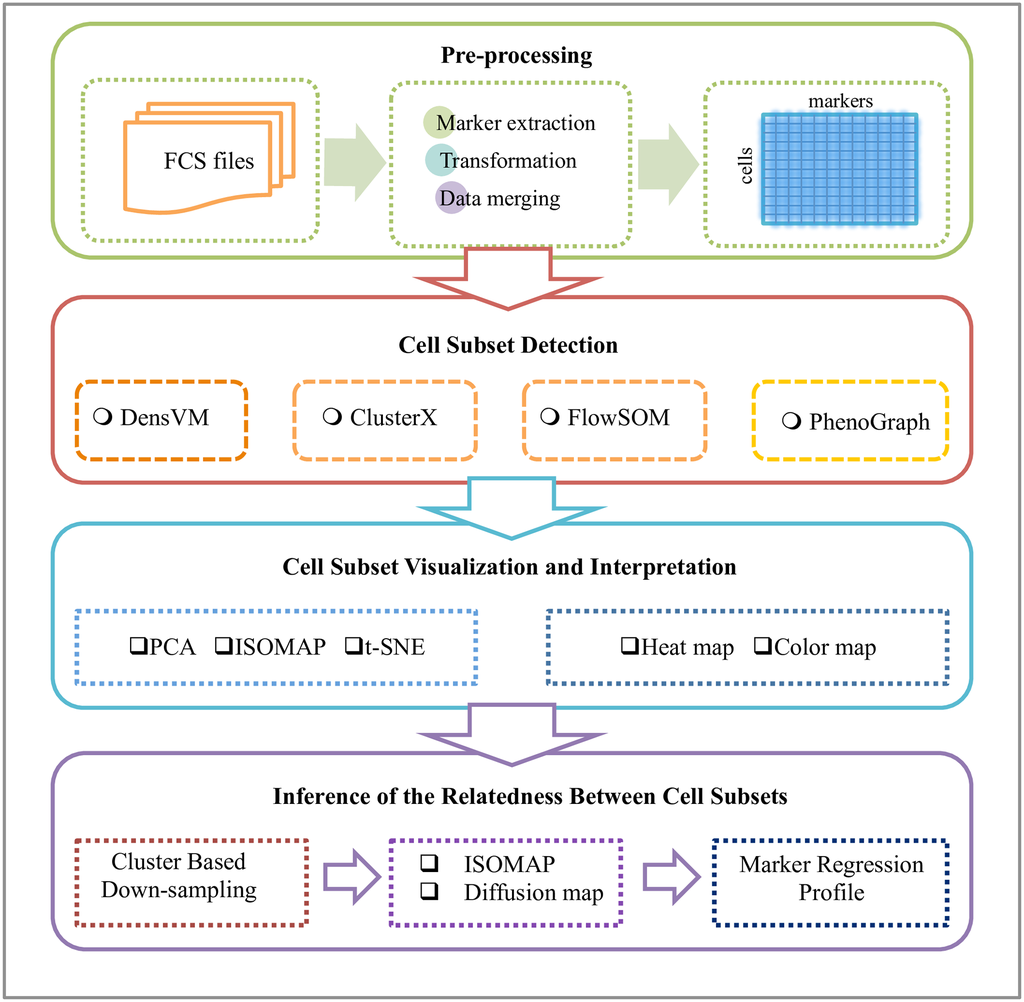